# HW3

Moushumi Pardesi

2023-04-14

```r
DFxts<-as.xts(DFdata, date_col=DFdata$Month)
periodicity(DFxts)
```

```
## Monthly periodicity from 2010-01-01 to 2019-06-01
```

```r
xts_train<-DFxts["2010-01-01/2018-12-31"]
xts_test<-DFxts["2019-01-01/2019-06-01"]
```

Ans1: The data is now split into train and test using the xts library.

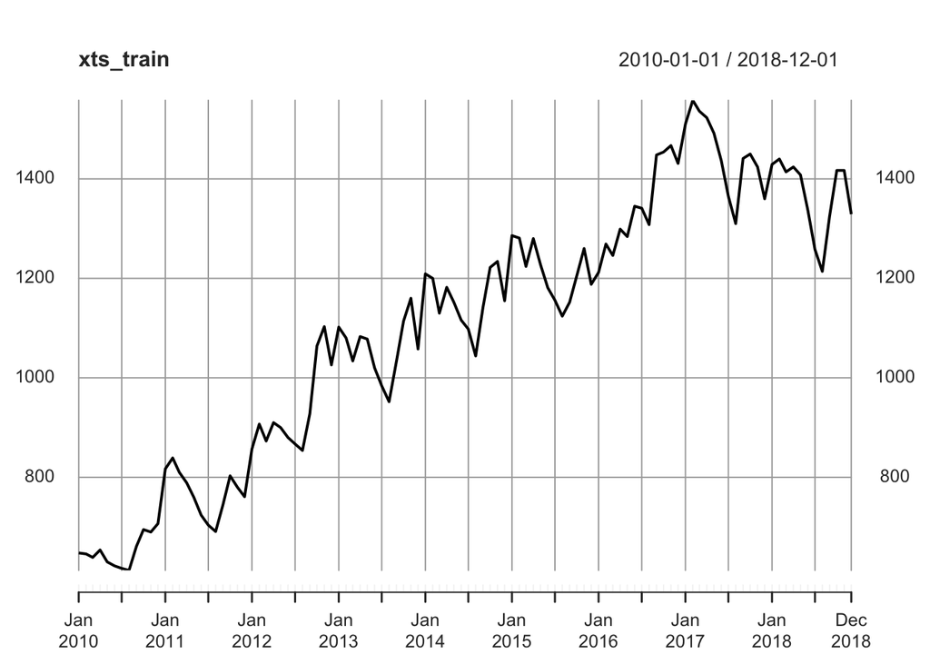

Ans2.1: After doing the EDA for this univariate time series, it seems like the timeseries is non-stationary (it has a trend). We can also conclude that The x-axis is neatly arranged in terms of date because an xts is a timeseries object in r which extensively works with time based data, taking in consideration its periodicity, etc.

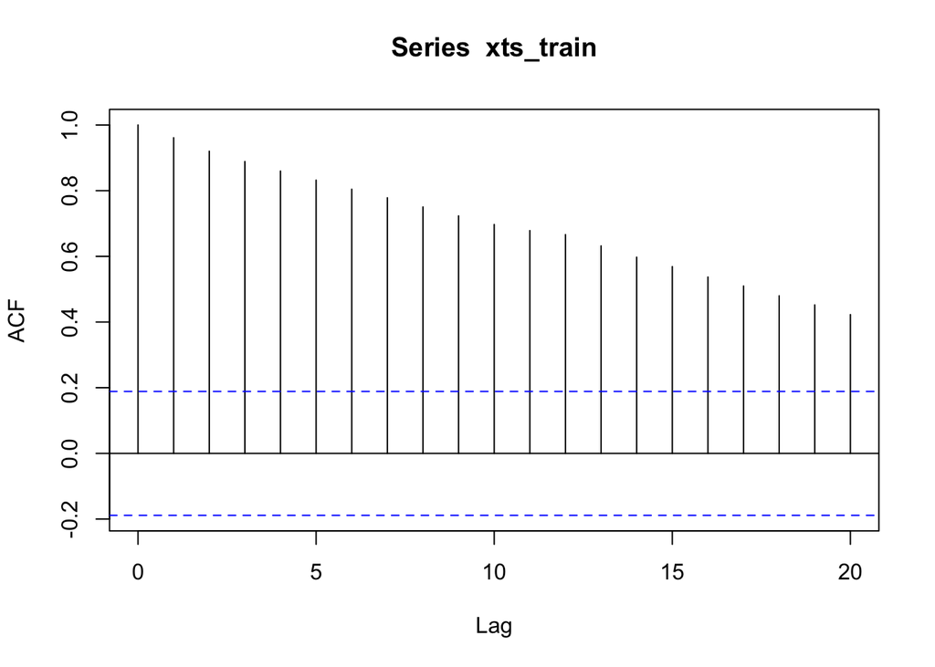

Ans2.2: plotted above

```
##
##  Augmented Dickey-Fuller Test
##
## data:  xts_train
## Dickey-Fuller = -2.1874, Lag order = 4, p-value = 0.4989
## alternative hypothesis: stationary
```

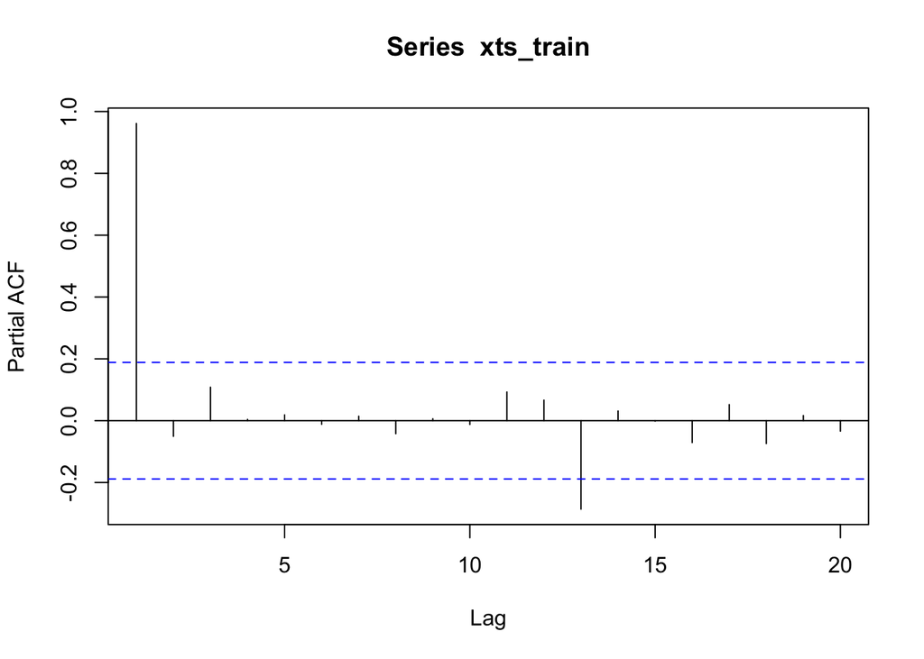

```
##
##  KPSS Test for Level Stationarity
##
## data:  xts_train
## KPSS Level = 2.0957, Truncation lag parameter = 4, p-value = 0.01
```

```
##    vars   n    mean     sd median trimmed    mad min  max range skew kurtosis
## X1    1 108 1104.48 269.16   1152 1113.47 312.09 613 1558   945 -0.3    -1.09
##      se
## X1 25.9
```

Ans3: The results we got in Q1 are confirmed by quantitative EDA. We see that the timeseries is non-stationary.

```
## Series: xts_train
## ARIMA(0,1,2) with drift
##
## Coefficients:
##           ma1      ma2   drift
##       -0.0447  -0.3104  6.6540
## s.e.   0.0966   0.1053  3.3997
##
## sigma^2 = 2997:  log likelihood = -578.7
## AIC=1165.4   AICc=1165.8   BIC=1176.09
##
## Training set error measures:
##                      ME     RMSE      MAE        MPE     MAPE     MASE
## Training set -0.1159702 53.72452 43.90696 -0.0956003 3.995772 0.973688
##                    ACF1
## Training set 0.01033776
```

Ans4: After applying auto arima with no seasonality, we can see the order of the model is (0,1,2). Therefore, p=0,d=1,q=2.

Ans5: Auto arima in the previous question returned d=1, which mean we had to take first differencing to make the series stationary. In case of a stationary series, d will be 0. Our EDA analysis concluded that the time series is non-stationary, which is confirmed by d.

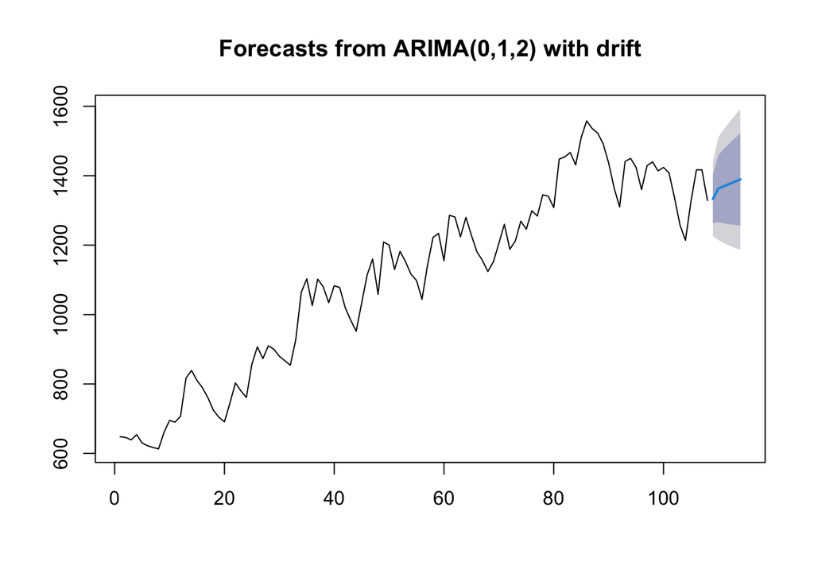

Ans6: Setting the h to 6 since the test set has 6 months data that we are forecasting.

```
##              ME     RMSE      MAE      MPE     MAPE
## Test set 40.511 70.39017 61.39005 2.754091 4.327492
```

Ans7: The above tests show that the forecast is fairly good. Mean error is non-zero which indicates bias in the forecast. Root mean squared error shows that the magnitude of errors in the forecast is fairly low. Mean absolute error is in line with the RMSE. Mean percentage error is non-zero but is close to zero which shows a good forecast. Mean absolute percentage error is low as well which indicates a reliable forecast.

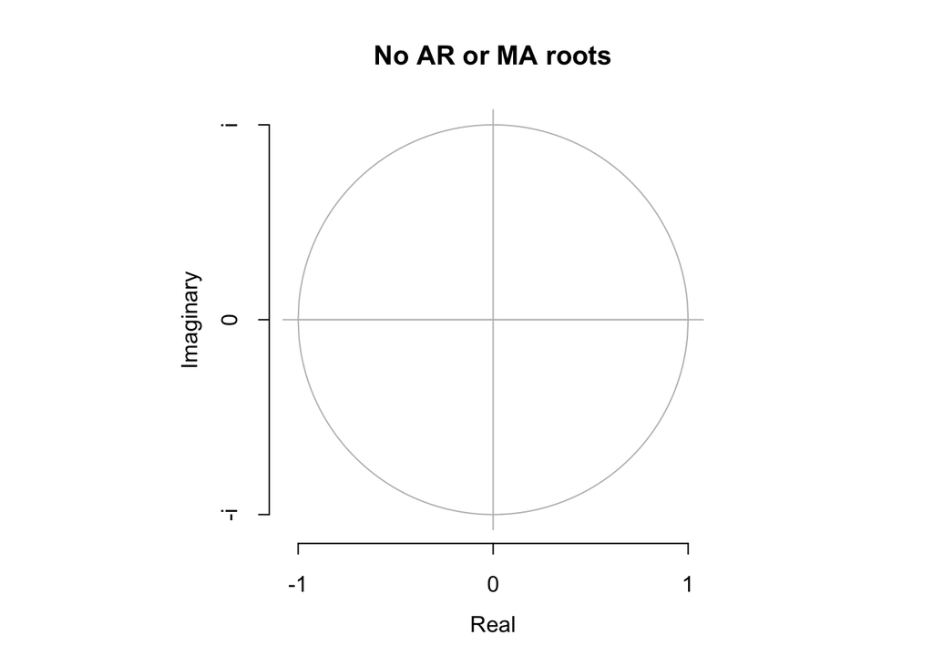

```
## Series: xts_train
## ARIMA(0,1,0)
##
## sigma^2 = 3194:  log likelihood = -583.52
## AIC=1169.04   AICc=1169.08   BIC=1171.72
##
## Training set error measures:
##                    ME    RMSE      MAE       MPE     MAPE      MASE        ACF1
## Training set 6.311556 56.2545 44.68193 0.5367033 4.038623 0.9908738 -0.02181436
```

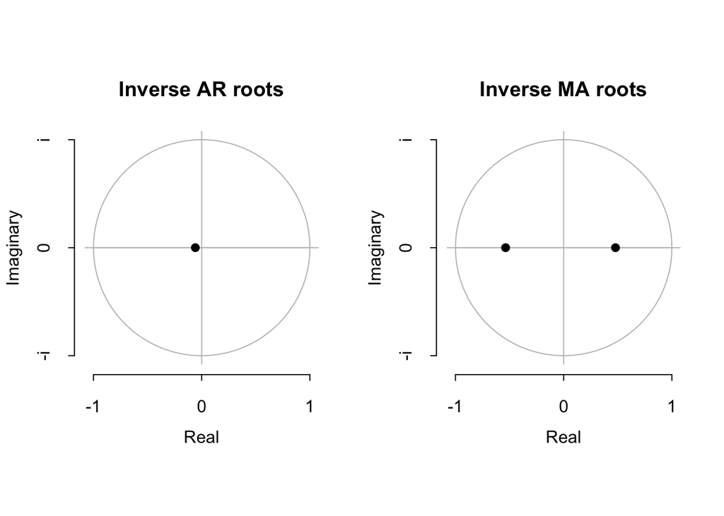

```
## Series: xts_train
## ARIMA(1,1,2)
##
## Coefficients:
##           ar1     ma1      ma2
##       -0.0586  0.0580  -0.2569
## s.e.   0.4459  0.4355   0.0998
##
## sigma^2 = 3090:  log likelihood = -580.29
## AIC=1168.59   AICc=1168.98   BIC=1179.28
##
## Training set error measures:
##                    ME     RMSE      MAE       MPE     MAPE      MASE
## Training set 8.490338 54.54799 42.98855 0.7366888 3.880337 0.9533213
##                     ACF1
## Training set -0.02716629
```

```
##                ME     RMSE      MAE      MPE     MAPE
## Test set 80.66667 90.90105 81.33333 5.636518 5.686756
```

```
##                ME     RMSE     MAE      MPE     MAPE
## Test set 71.31768 84.69919 76.0043 4.965505 5.318679
```

Ans9: The above shows forecast and accuracy for both the models. The accuracy of the forecast is compared with the actual test series.

Ans10.1: Root mean squared error for Model-2 is better than that of Model-1. p is 0 in Model-1 and 1 in Model-2. Since higher value of p helps capture the longer term dependency in the series, we can note that the series has longer term dependencies that we need to capture. Also, we can note that Model-2 has an unchanged q=2 as the original model, which could’ve helped capture short term dependencies (moving average).

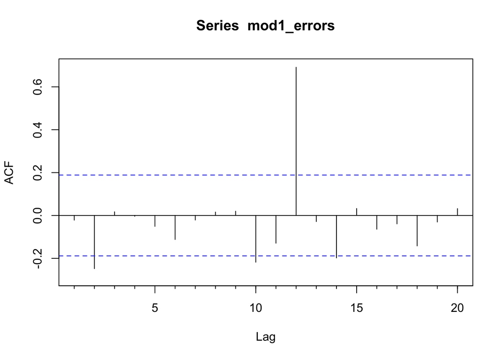

```
## [1] -0.02181436
```

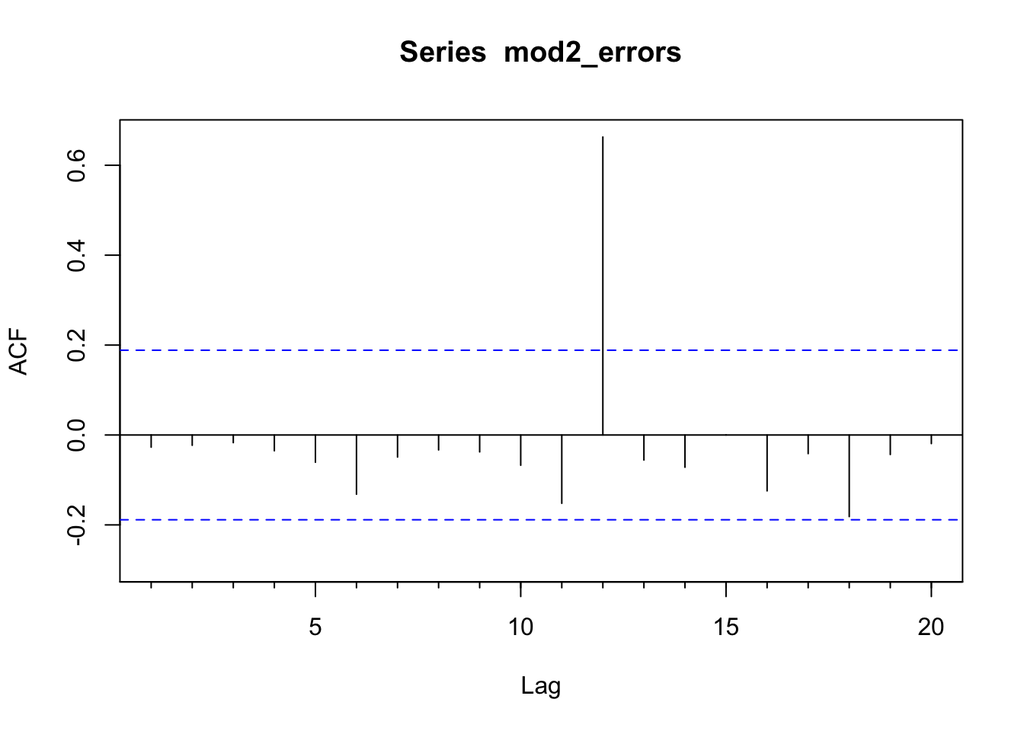

```
## [1] -0.02716629
```

Ans10.2:Both values of ACF1 are negative which means that the forecast errors have a negative correlation at lag 1. This means that if the forecast overestimates the value of the time series at a particular time point, then it is more likely to underestimate the value at the next time point, and vice versa. For reference, the ACF1 of the original model with p=0, d=1, and q=2 was positive but close to 0 (~0.010). Hence the original model gave us the most accurate forcast, compared to Model-1 and Model-2.